# R Notebook

```r
#ouverture du fichier
data=read.csv("dataR.csv",sep=",")
```

Fatma Bouchnag / Huan Jie Yen

# SAé 2.03 - Régression sur données réelles

Nous sommes fournis d’une base de données qui recense des données médicales concernant des patients atteints de tumeurs malignes ou bénignes. Chaque caractéristique spécifique des tumeurs est consciencieusement détaillée. Par conséquent, une analyse approfondie de ces caractéristiques est entreprise dans le but de déterminer la nature maligne ou bénigne de chaque tumeur présente dans la base de données. Cette analyse est réalisée en utilisant des méthodes statistiques afin d’extraire des informations significatives et discriminantes qui permettront de classer les tumeurs en fonction de leur nature malignes ou bénigne.

## 1.Représentation graphique de la proportion de tumeurs malignes et de tumeurs bénigne:

```r
diagnosis_counts <- table(data$diagnosis)
data$diagnosis <- factor(data$diagnosis, levels = c("B", "M"))
barplot(diagnosis_counts, main = "Proportion de tumeurs malignes et de tumeurs bénignes",
        xlab = "Diagnostique", ylab = "Effectif", col = c(rgb(1, 0, 0, alpha = 0.3), rgb(0, 0, 1, alpha = 0.3)))


legend("topright", legend = c("Malignes", "Benignes"), fill = c(rgb(1, 0, 0, alpha = 0.3),rgb(0, 0, 1, alpha = 0.3)))
```

[figure not shown]

```r
text(x = 1:length(diagnosis_counts), y = 1:length(diagnosis_counts), labels = diagnosis_counts, pos = 3)
```

Par observation de l’histogramme, nous avons un total de 357 tumeurs bénignes et 212 tumeurs malignes.

## 2.Représentation et analyse de l’histogramme du rayon (radius_mean)

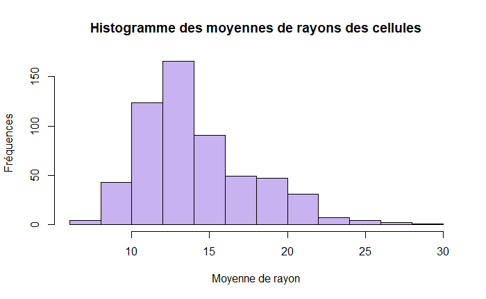

```r
hist(data$radius_mean,
     main = "Histogramme des moyennes de rayons des cellules",
     xlab = "Moyenne de rayon",
     ylab = "Fréquences",
     col = rgb(0.3, 0, 0.8, alpha = 0.3),
     border = "black")
```

## 3.Histogramme du rayon (radius_mean) différenciant les tumeurs malignes (M) et des bénignes (B):

```r
hist(data$radius_mean[data$diagnosis == "M"],
     main = "Histogramme du rayon des cellules",
     xlab = "Moyenne de rayon",
     ylab = "Fréquence",
     col = rgb(1, 0, 0, alpha = 0.3),
     border = "black",
     add = FALSE)  # Ajouter le premier histogramme

hist(data$radius_mean[data$diagnosis == "B"],
     col = rgb(0, 0, 1, alpha = 0.3),
     border = "black",
     add = TRUE)  # Ajouter le deuxième histogramme
```

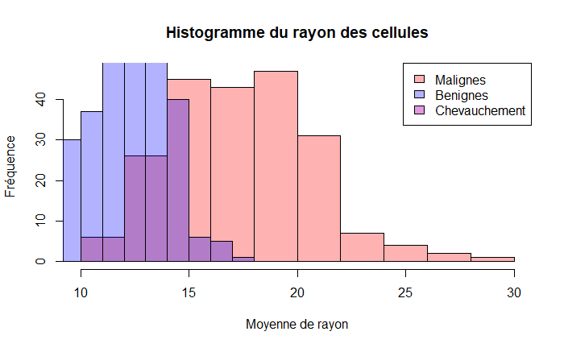

```r
# Couleur violette claire transparente pour le chevauchement
overlap_color <- rgb(0.7, 0, 0.7, alpha = 0.4)

# Légende avec le chevauchement
legend("topright", legend = c("Malignes", "Benignes", "Chevauchement"),
       fill = c(rgb(1, 0, 0, alpha = 0.3), rgb(0, 0, 1, alpha = 0.3), overlap_color))
```

On observe à partir de cet histogramme :

-Que la population de cellule maligne est majoritaire pour une moyenne de rayon de cellule supérieure à 15.

-Que la population de cellule bénigne est majoritaire pour une moyenne de rayon de cellule inférieure à 14.

-Que la population de cellule dont le rayon se trouve entre 14 et 15 est composée à proportion égale de cellules malignes et bénignes, puisque les populations se chevauchent.

Ainsi, il est possible d’en déduire que lorsque le rayon de la cellule tumorale est inférieur à 14 alors il y a de très forte chance qu’elle soit bénigne. Inversement, lorsque le rayon de la cellule tumorale est supérieur à 15, il y a de forte chance qu’elle soit maligne, et de surcroît si le rayon de la cellule se trouve entre 14 et 15 alors il est impossible d’en déduire assurément la nature de la cellule.

A noté que bien qu’une forte proportion de cellules bénignes a un rayon compris entre 12 et 14, une forte proportion de croisement de population est comprise dans cet intervalle.

De ce fait, nous pouvons affirmer que la variable du rayon des cellules est efficace pour discriminer la nature tumorale desdites cellules dont le rayon est compris entre 9 et 12 pour les cellules benignes et 15 et 30 pour les cellule malignes ; que cette variable perd en efficacité discriminatoire pour les valeurs comprises entre 12 et 15.

Isolons cette marge d’erreur afin de représenter sa répartition en fonction d’une autre variable:

```r
selected_data <- data[data$radius_mean >= 12 & data$radius_mean <= 15, c("concavity_mean", "diagnosis")]

# Créer l'histogramme pour la variable "concavity_mean" avec superposition des tumeurs
hist(selected_data[selected_data$diagnosis == "B", "concavity_mean"], col = rgb(0, 0, 1, alpha = 0.3), main = "Répartition des tumeurs en fonction de concavity_mean", xlab = "concavity_mean", ylab = "Fréquence", xlim = c(0, max(selected_data$concavity_mean)))
hist(selected_data[selected_data$diagnosis == "M", "concavity_mean"], col = rgb(1, 0, 0, alpha = 0.3), add = TRUE)
```

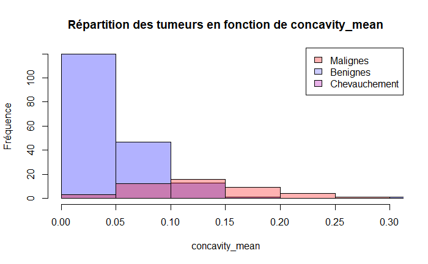

```r
#Légende
legend("topright", legend = c("Malignes", "Benignes", "Chevauchement"),
       fill = c(rgb(1, 0, 0, alpha = 0.3), rgb(0, 0, 1, alpha = 0.2), overlap_color))
```

La marge d’erreur de la moyenne de rayon est ici isolée et répartie en fonction de la variable concavity_mean. On observe que lorsque la concavité est comprise entre 0.00 et 0.10, il y a de forte chance que la cellule tumorale soit bénigne. En revanche, lorsqu’elle est supérieure à 0.15, la cellule tumorale a de forte chance d’être maligne.

Nous pouvons effectuer le même processus en utilisant une autre variable afin de discriminer la marge d’erreur.

## 4.Histogramme des dix variables statistiques représentant les tumeurs malignes et bénignes.

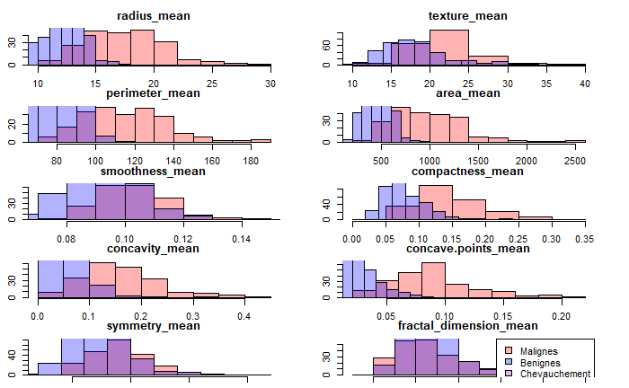

```r
#les colonnes pertinentes pour les histogrammes
selected_cols <- c("radius_mean", "texture_mean", "perimeter_mean", "area_mean", "smoothness_mean", "compactness_mean", "concavity_mean", "concave.points_mean", "symmetry_mean", "fractal_dimension_mean", "diagnosis")
selected_data <- data[, selected_cols]

#données en deux groupes : tumeurs malignes (M) et bénignes (B) en fonction de la colonne "diagnosis"
malignes <- selected_data[selected_data$diagnosis == "M", ]
benignes<- selected_data[selected_data$diagnosis == "B", ]


par(mfrow = c(5, 2))  # 5 lignes, 2 colonnes
par(mar = c(1, 2.5, 2.5, 3))  # Réduire les marges intérieures


for (i in 1:10) {
  hist(malignes[, i], col = rgb(1, 0, 0, alpha = 0.3), main = colnames(malignes)[i], add = FALSE)
  hist(benignes[, i], col = rgb(0, 0, 1, alpha = 0.3), main = colnames(benignes)[i], add = TRUE)
}

overlap_color <- rgb(0.7, 0, 0.7, alpha = 0.3)



legend("topright", legend = c("Malignes", "Benignes", "Chevauchement"),
       fill = c(rgb(1, 0, 0, alpha = 0.3), rgb(0, 0, 1, alpha = 0.3), overlap_color))
```

-rayon moyen -texture moyen -périmètre moyen -aire moyen -finesse moyenne -compacité moyenne -concavité moyenne -points concaves moyen -symétrie moyenne -dimension fractale

## 5.Déductions des variables discriminantes afin de déterminer l’état de la tumeur.

Dans un premier temps, nous allons analyser la dispersion des barres pour chaque diagnostique (Bénin ou Malin). Si la différence de dispertion est grande, on peut supposer que la variable nous permets de déterminer le diagnostique.

Par interprétation graphique, on remarque que pour la variable de l’aire, les tumeurs malignes ont tendances à avoir une aire supérieure à 600. Par ailleurs, les tumeurs bénignes ont tendance à avoir une aire inférieure à 600. Cette dispersion notable nous permets d’en déduire que la variable de l’aire est une variable discriminante.

On note également que le périmètre d’une cellule étant maligne a tendance à être supérieur à 100, à l’inverse des tumeurs bénignes, ou nous voyons qu’elles sont généralement inférieures à 100. Cette différence nous permets également de déduire que la variable du périmètre est une variable discriminante.

## 6 Nuage de points relatif à la texture en fonction du rayon

```r
selected_data <- data[, c("radius_mean", "diagnosis", "texture_mean")]
malignant_data <- selected_data[selected_data$diagnosis == "M", ]
benign_data <- selected_data[selected_data$diagnosis == "B", ]

plot(malignant_data$radius_mean, malignant_data$texture_mean, col = rgb(1, 0, 0, alpha = 0.3), xlab = "Rayon", ylab = "Texture")
points(benign_data$radius_mean, benign_data$texture_mean, col = rgb(0, 0, 1, alpha = 0.3))
```

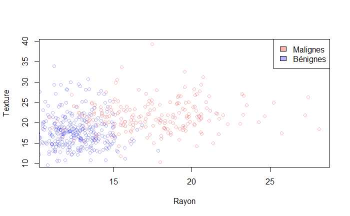

```r
# Légende
legend("topright", legend = c("Malignes", "Bénignes"), fill = c(rgb(1, 0, 0, alpha = 0.3), rgb(0, 0, 1, alpha = 0.3)))
```

Le nuage de points est constitué de deux types de points : rouge et bleu. Les points rouges représentent les tumeurs malignes, tandis que les points bleus représentent les tumeurs bénignes. L’axe des y représente la texture des tumeurs. L’axe des x représente le rayon des tumeurs.

Par lecture graphique: Les points bleus, représentant les tumeurs bénignes, sont centrés dans un intervalle inférieur à 15 pour le rayon. Cette observation suggère une corrélation entre les tumeurs bénignes et des rayons plus faibles.

Les points rouges, représentant les tumeurs malignes, se dispersent à partir d’un rayon de 15. Cela indique une corrélation entre les tumeurs malignes et des rayons plus élevés. La dispersion des points rouges suggère qu’il existe une plus grande variabilité de tailles de tumeurs malignes dans l’échantillon.

Une corrélation significative est observée entre les types de tumeurs (bénignes/malignes) et le rayon des tumeurs. Les tumeurs bénignes ont tendance à avoir des rayons plus faibles et à se regrouper, tandis que les tumeurs malignes présentent une plus grande variabilité de tailles.

L’analyse du nuage de points révèle également qu’il n’y a pas de corrélation évidente entre la texture des tumeurs et leur rayon.

Pour évaluer la pertinence de cette affirmation, nous pouvons procéder à un calcul de Pearson:

```r
X <- data[, c("radius_mean")]
Y <- data[, c("texture_mean")]

cor(X,Y)
```

[output not shown]

Avec un résultat de Pearson 0.3, on estime la valeur trop faible pour affirmer une quelconque corrélation.

## 7.

Voici les variables isolées précédemment : le rayon, la texture, la compacité, la concavité, l’aire, les points concaves et le périmètre

Lors de l’analyse de grandes quantités de données, il est utile de réduire le nombre de variables à considérer. La matrice de corrélation permet d’identifier les variables qui sont fortement corrélées les unes aux autres. Dans ce cas, il est possible de choisir une seule variable représentative d’un groupe de variables fortement corrélées.

En effet, lorsqu’il y a une forte corrélation entre deux variables, cela signifie qu’elles sont très similaires dans leur comportement et qu’elles apportent essentiellement la même information à l’analyse. Dans ce cas, on peut choisir de supprimer l’une des deux variables pour éviter la redondance.

La matrice de corrélation ci-dessous:

```r
selected_data <- data[, c("concave.points_mean", "radius_mean", "diagnosis", "texture_mean","perimeter_mean", "area_mean", "compactness_mean", "concavity_mean")]
malignant_data <- selected_data[selected_data$diagnosis == "M", ]
benign_data <- selected_data[selected_data$diagnosis == "B", ]
```

```r
selected_data <- data[, c("concave.points_mean", "radius_mean", "texture_mean", "perimeter_mean", "area_mean", "compactness_mean", "concavity_mean")]
correlation_matrix <- cor(selected_data)
print(correlation_matrix)
```

```
                    concave.points_mean radius_mean texture_mean perimeter_mean area_mean compactness_mean concavity_mean
concave.points_mean           1.0000000   0.8225285    0.2934641      0.8509770 0.8232689        0.8311350      0.9213910
radius_mean                   0.8225285   1.0000000    0.3237819      0.9978553 0.9873572        0.5061236      0.6767636
texture_mean                  0.2934641   0.3237819    1.0000000      0.3295331 0.3210857        0.2367022      0.3024178
perimeter_mean                0.8509770   0.9978553    0.3295331      1.0000000 0.9865068        0.5569362      0.7161357
area_mean                     0.8232689   0.9873572    0.3210857      0.9865068 1.0000000        0.4985017      0.6859828
compactness_mean              0.8311350   0.5061236    0.2367022      0.5569362 0.4985017        1.0000000      0.8831207
concavity_mean                0.9213910   0.6767636    0.3024178      0.7161357 0.6859828        0.8831207      1.0000000
```

D’après la matrice de corrélation, voici les paires de variables qui ont une corrélation élevée :

concave.points_mean/radius_mean 0.8225285

concave.points_mean/perimeter_mean 0.8509770

concave.points_mean/area_mean 0.8232689

concave.points_mean/compactness_mean 0.8311350

concave.points_mean/concavity_mean 0.9213910

radius_mean/perimeter_mean 0.9978553

radius_mean/area_mean 0.9873572

perimeter_mean/ area_mean 0.9865068

compactness_mean/concavity_mean 0.8831207

Nous pouvons visualiser ces corrélations ainsi que leur ajustement linéaire par la méthode des moindres carrées avec les nuages de points ci-dessous:

Points concave:

```r
# Diviser la fenêtre graphique en 1 ligne et 1 colonne
par(mfrow = c(1, 1))

#on ajoute les plots

# Création du graphique de dispersion
plot(malignant_data$concave.points_mean, malignant_data$radius_mean, col = "red", xlab = "Points concave", ylab = "Rayon")
points(benign_data$concave.points_mean, benign_data$radius_mean, col = "blue")
```

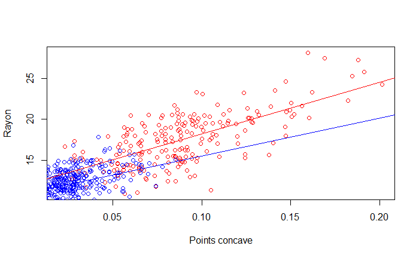

```r
# Ajustement linéaire des moindres carrés pour les tumeurs malignes
model_malignant <- lm(radius_mean ~ concave.points_mean, data = malignant_data)
abline(model_malignant, col = "red")

# Ajustement linéaire des moindres carrés pour les tumeurs bénignes
model_benign <- lm(radius_mean ~ concave.points_mean, data = benign_data)
abline(model_benign, col = "blue")
```

```r
# Création du graphique de dispersion
plot(malignant_data$concave.points_mean, malignant_data$perimeter_mean, col = "red", xlab = "Points concave", ylab = "Périmètre")
points(benign_data$concave.points_mean, benign_data$perimeter_mean, col = "blue")
```

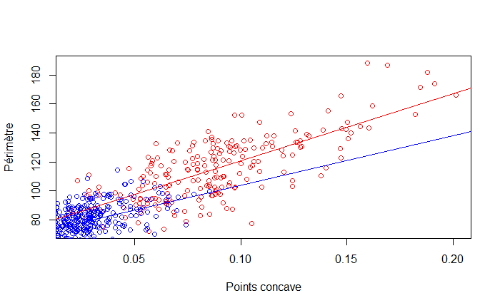

```r
# Ajustement linéaire des moindres carrés pour les tumeurs malignes
model_malignant <- lm(perimeter_mean ~ concave.points_mean, data = malignant_data)
abline(model_malignant, col = "red")

# Ajustement linéaire des moindres carrés pour les tumeurs bénignes
model_benign <- lm(perimeter_mean ~ concave.points_mean, data = benign_data)
abline(model_benign, col = "blue")
```

```r
# Création du graphique de dispersion
plot(malignant_data$concave.points_mean, malignant_data$area_mean, col = "red", xlab = "Points concave", ylab = "Aire")
points(benign_data$concave.points_mean, benign_data$area_mean, col = "blue")
```

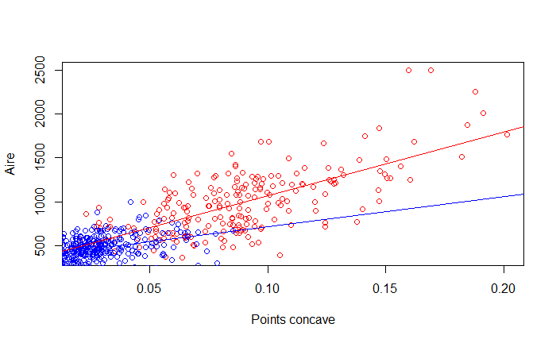

```r
# Ajustement linéaire des moindres carrés pour les tumeurs malignes
model_malignant <- lm(area_mean ~ concave.points_mean, data = malignant_data)
abline(model_malignant, col = "red")

# Ajustement linéaire des moindres carrés pour les tumeurs bénignes
model_benign <- lm(area_mean ~ concave.points_mean, data = benign_data)
abline(model_benign, col = "blue")
```

```r
# Création du graphique de dispersion
plot(malignant_data$concave.points_mean, malignant_data$compactness_mean, col = "red", xlab = "Points concave", ylab = "Compacité")
points(benign_data$concave.points_mean, benign_data$compactness_mean, col = "blue")
```

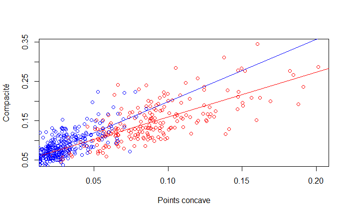

```r
# Ajustement linéaire des moindres carrés pour les tumeurs malignes
model_malignant <- lm(compactness_mean ~ concave.points_mean, data = malignant_data)
abline(model_malignant, col = "red")

# Ajustement linéaire des moindres carrés pour les tumeurs bénignes
model_benign <- lm(compactness_mean ~ concave.points_mean, data = benign_data)
abline(model_benign, col = "blue")
```

```r
# Création du graphique de dispersion
plot(malignant_data$concave.points_mean, malignant_data$concavity_mean, col = "red", xlab = "Points concave", ylab = "Concavité")
points(benign_data$concave.points_mean, benign_data$concavity_mean, col = "blue")
```

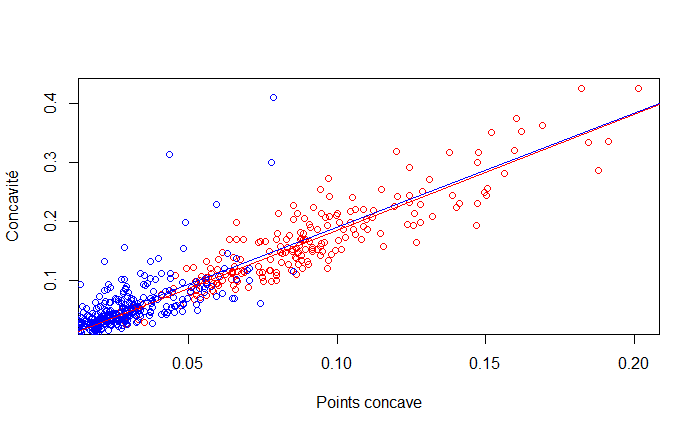

```r
# Ajustement linéaire des moindres carrés pour les tumeurs malignes
model_malignant <- lm(concavity_mean ~ concave.points_mean, data = malignant_data)
abline(model_malignant, col = "red")

# Ajustement linéaire des moindres carrés pour les tumeurs bénignes
model_benign <- lm(concavity_mean ~ concave.points_mean, data = benign_data)
abline(model_benign, col = "blue")
```

```r
NA
NA
```

La concavité et les points concaves étant deux variables très corrélées car très liées, nous opterons pour l’utilisation de la variable de concavité au détriment de la variable des points concaves.

Rayon:

```r
# Diviser la fenêtre graphique en 2 ligne et 2 colonnes
par(mfrow = c(1, 2))

# Création du graphique de dispersion
plot(malignant_data$radius_mean, malignant_data$perimeter_mean, col = "red", xlab = "Rayon", ylab = "Périmètre")
points(benign_data$radius_mean, benign_data$perimeter_mean, col = "blue")
```

```r
# Ajustement linéaire des moindres carrés pour les tumeurs malignes
model_malignant <- lm(perimeter_mean ~ radius_mean, data = malignant_data)
abline(model_malignant, col = "red")

# Ajustement linéaire des moindres carrés pour les tumeurs bénignes
model_benign <- lm(perimeter_mean ~ radius_mean, data = benign_data)
abline(model_benign, col = "blue")
```

```r
# Création du graphique de dispersion
plot(malignant_data$radius_mean, malignant_data$area_mean, col = "red", xlab = "Rayon", ylab = "Aire")
points(benign_data$radius_mean, benign_data$area_mean, col = "blue")
```

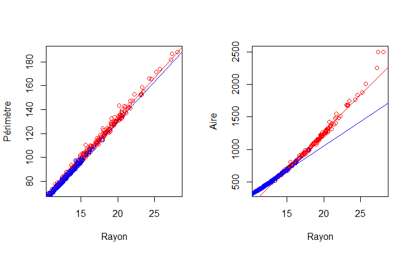

```r
# Ajustement linéaire des moindres carrés pour les tumeurs malignes
model_malignant <- lm(area_mean ~ radius_mean, data = malignant_data)

# Ajustement linéaire des moindres carrés pour les tumeurs bénignes
model_benign <- lm(area_mean ~ radius_mean, data = benign_data)

# Ajout des droites de régression
abline(model_malignant, col = "red")
abline(model_benign, col = "blue")
```

Il est raisonnable de supposer qu’il existe une corrélation entre les variables du périmètre et du rayon. En effet, le rayon d’un cercle est directement lié au périmètre, car le périmètre est proportionnel au rayon selon la formule mathématique 2πr.

De même, il est attendu qu’il y ait une corrélation évidente entre le rayon et l’aire des cercles. La connaissance du rayon seul est suffisante pour calculer l’aire d’un cercle.

Lors de l’analyse de données impliquant le rayon et l’aire de cercles, il peut être redondant ou superflu de conserver toutes les variables de ces modèles. Il est donc possible de supprimer l’une des variables sans perdre beaucoup d’informations, car elles fournissent essentiellement la même information de base.

De ce fait, nous garderons le rayon.

Compacité:

```r
# Création du graphique de dispersion
plot(malignant_data$compactness_mean, malignant_data$concavity_mean, col = "red", xlab = "Compacité", ylab = "Concavité")
points(benign_data$compactness_mean, benign_data$concavity_mean, col = "blue")
```

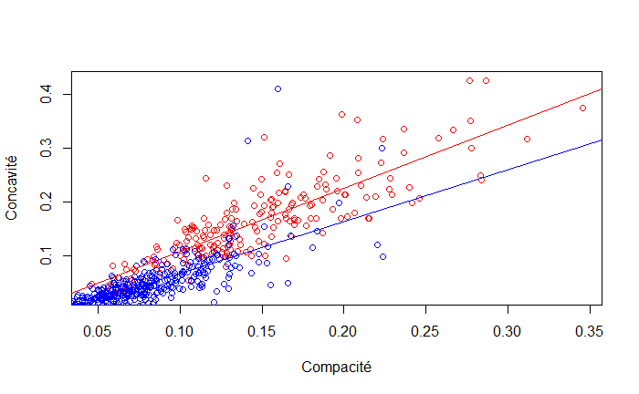

```r
# Ajustement linéaire des moindres carrés pour les tumeurs malignes
model_malignant <- lm(concavity_mean ~ compactness_mean, data = malignant_data)
abline(model_malignant, col = "red")

# Ajustement linéaire des moindres carrés pour les tumeurs bénignes
model_benign <- lm(concavity_mean ~ compactness_mean, data = benign_data)
abline(model_benign, col = "blue")
```

L’ajustement linéaire pour les tumeurs bénignes montre une tendance générale où les points sont regroupés vers la gauche de la droite. Cela suggère une relation positive entre la compacité et la concavité pour les tumeurs bénignes. En d’autres termes, à mesure que la compacité augmente, la concavité tend également à augmenter pour les tumeurs bénignes. Le regroupement des points vers la gauche indique une faible variabilité dans cette relation, ce qui implique que les tumeurs bénignes ont tendance à présenter des valeurs de compacité et de concavité relativement faibles et similaires.

La corrélation de Pearson de 0.8831207 suggère une corrélation forte et positive entre la compacité et la concavité dans l’ensemble de données comprenant à la fois les tumeurs bénignes et malignes. Cependant, la dispersion importante des points vers la fin de l’ajustement linéaire des tumeurs malignes indique qu’il existe une variabilité importante dans cette relation, même avec une corrélation élevée.

Bien qu’elles soient corrélées, la compacité et la concavité n’apportent toutes les deux pas la même information, à l’inverse du rayon, du périmètre et de l’aire. Ainsi, il est préférable de les garder.

En conclusion, les variables restantes sont les plus discriminantes, s’agissant du rayon des cellules, de la concavité ainsi que de la compacité. Grâce à elles, nous pouvons identifier les tumeurs malignes des tumeurs bénignes.